# My First Mardown Document

Ethan Dean

16 Feburary 2021

Add text here. Just use it like a typewriter, and add as much or as little as you like.

New text appears here in a separate paragraph.

Ethan Dean  
Department of Biology  
University of Vermont

Use 2 or more blank spaces at the end of a single-spaced line.

# Basic text formatting

italic *text* like this

bold **text** like this

subscript<sub>text</sub> like this

superscript<sup>text</sup> like this

strikesthrough text like this

# Lists

## Unordered Lists

- Item 1
- Item 2
  - Item 2a
  - Item 2b

## Ordered Lists

1. Item 1
2. Item 2
3. Item 3
   - Item 3a
   - Item 3b

# Fencing

In line fencing with a backtick `to show anything in plain text with *no* formatting` which can be useful for many things.

In line execution of R inside the backticks by inserting R as the first element 6.1415927

In line execution of R inside the backticks by inserting R as the first element `3 + pi`

3 backticks for a whole section of plain text

```
everything in here is in plain text.
even single lines.

useful especially when showing other coding instructions.
```

# Block Quotes with `>`

> To be or not to be, that is the question. Whether tis nobler… blah blah blah

# Spacer line with 3 or more understcores

Adds a line between text…

# Links

http://example.com

[Linked phrase](http://example.com)

A [linked phrase](http://example.com/).

At the bottom of the document:

Images

# Images

`![alt text](http://example.com/logo.png)`

`![alt text](figures/img.png)`

# Table

| First Header | Second Header |
| --- | --- |
| Content Cell | **Formatted Text** |
| Content Cell | *Formatted Text* |

# LaTek code for equations

We set off equations with `$` for brackets.

## In-line versus stand-alone equations

These equations such as $a = 3 + 4$ will appear inside a single line of text.

These equations such as
$$a = 3 + 4$$
will appear in a separate line of their own.

## Subscripts

$$H_0 = Z_{a + b}$$

## Superscripts

$$S = cA^z$$

Elements can be coupled and nested

$$S=cA^z_1 +z_{2+x}$$

## Fractions and Greek symbols

$$\alpha = \frac{\beta}{\delta + \gamma_x}$$

## Summation Signs

$$z= \sum_{i=1}^X{K}$$
## Escape the backslash with a custom term

$$\backslash \alpha \le b \backslash$$

## Rendering plaintext in a LaTex equation

$$P(occurance of Species A) = Z$$

$$P(\mbox{Occurence of species A}) = Z$$

#R in Markdown

```r
# Don't forget to start with comments!
# Preliminaries
library(ggplot2)

pred <- 1:10 #Vector of 10 integers
res <- runif(10) # Random Uniform Values

# Print the random numbers
print(res)
```

```
##  [1] 0.90316073 0.41905613 0.63965658 0.53449238 0.03575643 0.03450108
##  [7] 0.40498475 0.40122932 0.18980742 0.19578227
```

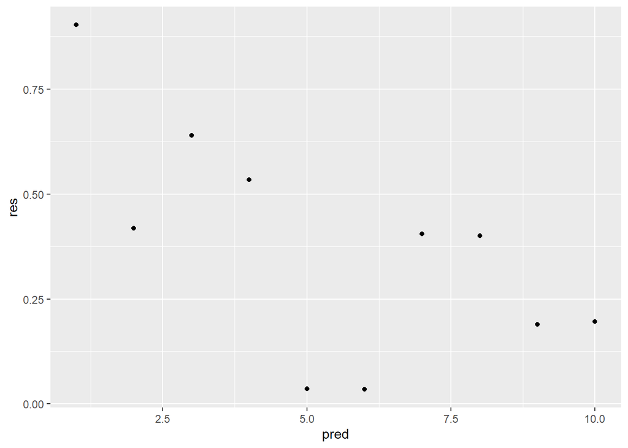

```r
#plot the graph
qplot(x=pred,y=res)
```

Now back to writing text in our markdown document, including latex equations if we need them such as $a+b$ inserted in the middle of my sentence